# R Notebook

# Weekend homework - Model Building

Load in libraries and data

```r
library(broom)
```

```r
red <- read_csv("data/wine_quality_red.csv")
white <- read.csv("data/wine_quality_white.csv")
```

```r
names(white)
```

```
 [1] "wine_id"              "fixed_acidity"        "volatile_acidity"     "citric_acid"          "residual_sugar"
 [6] "chlorides"            "free_sulfur_dioxide"  "total_sulfur_dioxide" "density"              "p_h"
[11] "sulphates"            "alcohol"              "quality"              "region"
```

```r
names(red)
```

```
 [1] "wine_id"              "fixed_acidity"        "volatile_acidity"     "citric_acid"          "residual_sugar"
 [6] "chlorides"            "free_sulfur_dioxide"  "total_sulfur_dioxide" "density"              "p_h"
[11] "sulphates"            "alcohol"              "quality"              "region"
```

| wine_id | fixed_acidity | volatile_acidity | citric_acid | residual_sugar | chlorides | free_sulfur_dioxide | total_sulfur_dioxide | density | p_h | sulphates | alcohol | quality | region |
| --- | --- | --- | --- | --- | --- | --- | --- | --- | --- | --- | --- | --- | --- |
| 1 | 7.4 | 0.70 | 0.00 | 1.9 | 0.076 | 11 | 34 | 0.9978 | 3.51 | 0.56 | 9.4 | 4.66 | Australia |
| 2 | 7.8 | 0.88 | 0.00 | 2.6 | 0.098 | 25 | 67 | 0.9968 | 3.20 | 0.68 | 9.8 | 4.82 | Spain |
| 3 | 7.8 | 0.76 | 0.04 | 2.3 | 0.092 | 15 | 54 | 0.9970 | 3.26 | 0.65 | 9.8 | 4.91 | Spain |
| 4 | 11.2 | 0.28 | 0.56 | 1.9 | 0.075 | 17 | 60 | 0.9980 | 3.16 | 0.58 | 9.8 | 5.96 | Australia |
| 5 | 7.4 | 0.70 | 0.00 | 1.9 | 0.076 | 11 | 34 | 0.9978 | 3.51 | 0.56 | 9.4 | 5.42 | Italy |
| 6 | 7.4 | 0.66 | 0.00 | 1.8 | 0.075 | 13 | 40 | 0.9978 | 3.51 | 0.56 | 9.4 | 4.78 | Italy |

## Step 1: join the two datasets together to look for correlations

```r
red$type <- "Red"
white$type <-"White"

wines <- bind_rows(red, white)
```

```r
wines_trim <- wines%>%
  select(-wine_id)
```

```r
summary(wines)
```

```
    wine_id     fixed_acidity    volatile_acidity  citric_acid     residual_sugar     chlorides       free_sulfur_dioxide
 Min.   :   1   Min.   : 3.800   Min.   :0.0800   Min.   :0.0000   Min.   : 0.600   Min.   :0.00900   Min.   :  1.00
 1st Qu.: 813   1st Qu.: 6.400   1st Qu.:0.2300   1st Qu.:0.2500   1st Qu.: 1.800   1st Qu.:0.03800   1st Qu.: 17.00
 Median :1650   Median : 7.000   Median :0.2900   Median :0.3100   Median : 3.000   Median :0.04700   Median : 29.00
 Mean   :2044   Mean   : 7.215   Mean   :0.3397   Mean   :0.3186   Mean   : 5.443   Mean   :0.05603   Mean   : 30.53
 3rd Qu.:3274   3rd Qu.: 7.700   3rd Qu.:0.4000   3rd Qu.:0.3900   3rd Qu.: 8.100   3rd Qu.:0.06500   3rd Qu.: 41.00
 Max.   :4898   Max.   :15.900   Max.   :1.5800   Max.   :1.6600   Max.   :65.800   Max.   :0.61100   Max.   :289.00
 total_sulfur_dioxide    density            p_h          sulphates         alcohol         quality         region
 Min.   :  6.0        Min.   :0.9871   Min.   :2.720   Min.   :0.2200   Min.   : 8.00   Min.   :2.530   Length:6497
 1st Qu.: 77.0        1st Qu.:0.9923   1st Qu.:3.110   1st Qu.:0.4300   1st Qu.: 9.50   1st Qu.:5.150   Class :character
 Median :118.0        Median :0.9949   Median :3.210   Median :0.5100   Median :10.30   Median :5.860   Mode  :character
 Mean   :115.7        Mean   :0.9947   Mean   :3.219   Mean   :0.5313   Mean   :10.49   Mean   :5.844
 3rd Qu.:156.0        3rd Qu.:0.9970   3rd Qu.:3.320   3rd Qu.:0.6000   3rd Qu.:11.30   3rd Qu.:6.400
 Max.   :440.0        Max.   :1.0390   Max.   :4.010   Max.   :2.0000   Max.   :14.90   Max.   :9.440
     type
 Length:6497
 Class :character
 Mode  :character
```

### Group wines by properties, and another group for acidities and analyse with ggplots, grouping by type (red/ white)

```r
wines_group1 <- wines_trim %>%
  select(quality, density, p_h, alcohol, region, residual_sugar, type)
```

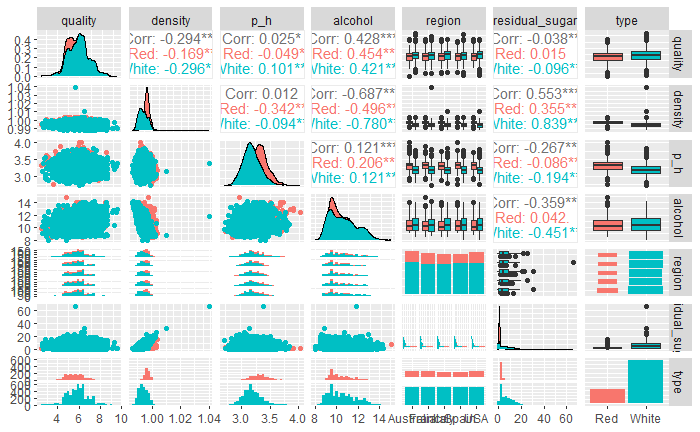

```r
wines_group1 %>%
  ggpairs(aes(colour = type))
```

Group 2 for acidity and sulphates

```r
wines_group2 <- wines_trim %>%
  select(quality, fixed_acidity, volatile_acidity, citric_acid, chlorides, free_sulfur_dioxide, total_sulfur_dioxide, sulphates, type)
```

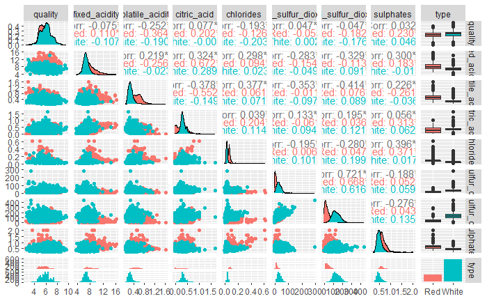

```r
wines_group2 %>%
  ggpairs(aes(colour = type))
```

From both ggplots we see distinctly different properties for red and white wines, which would make a model difficult to build. For example, sulphates correlate to quality at 0.23 for red, but 0.046 for white. And density correlates -0.296 to quality for white, but -0.169 for red.

Region exploration

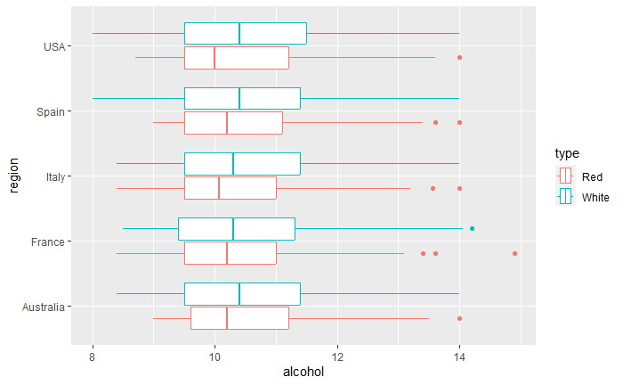

```r
wines %>%
  ggplot(aes(x = alcohol, y = region, colour = type))+
  geom_boxplot()
```

## Red wine ggpairs

```r
red_group1 <- red %>%
  select(quality, p_h, density, alcohol, region, residual_sugar)
```

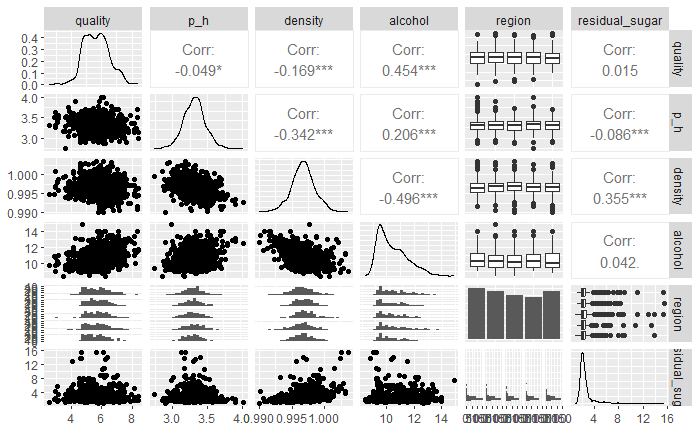

```r
red_group1 %>%
  ggpairs()
```

```r
red_group2 <- red  %>%
  select(quality, fixed_acidity, volatile_acidity, citric_acid, chlorides, free_sulfur_dioxide, total_sulfur_dioxide, sulphates)
```

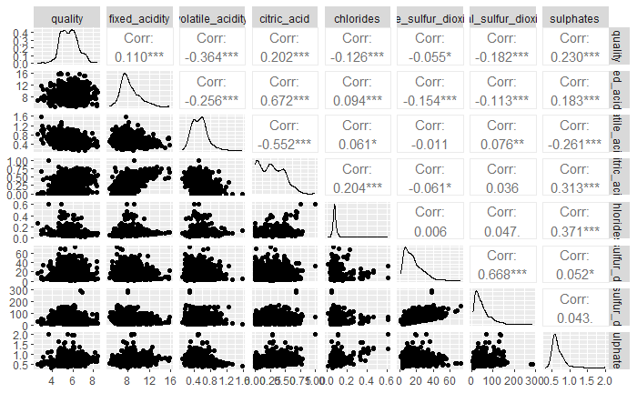

```r
red_group2 %>%
  ggpairs()
```

### Red wines - model building

Top correlation for red wine is with alcohol

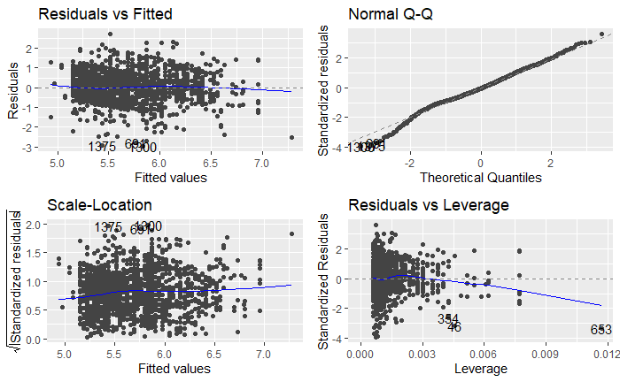

```r
red_trim <- red %>%
  select(-c(wine_id, type))

mod1_red <- lm(quality ~ alcohol, data = red_trim)

autoplot(mod1_red)
```

```r
summary(mod1_red)
```

```
Call:
lm(formula = quality ~ alcohol, data = red_trim)

Residuals:
     Min       1Q   Median       3Q      Max
-2.95517 -0.50166 -0.04501  0.49519  2.70011

Coefficients:
            Estimate Std. Error t value Pr(>|t|)
(Intercept)  1.89570    0.18603   10.19   <2e-16 ***
alcohol      0.36142    0.01776   20.36   <2e-16 ***
---
Signif. codes:  0 ‘***’ 0.001 ‘**’ 0.01 ‘*’ 0.05 ‘.’ 0.1 ‘ ’ 1

Residual standard error: 0.7564 on 1597 degrees of freedom
Multiple R-squared:  0.206, Adjusted R-squared:  0.2055
F-statistic: 414.4 on 1 and 1597 DF,  p-value: < 2.2e-16
```

Diagnostic plots look good, plot 1, 2 and 3 should normal distribution for residuals.

The R^2 = 0.206 and the result is statistically significant.

```r
red_resid <- red_trim %>%
  add_residuals(model = mod1_red) %>%
  select(-c(quality, alcohol))
```

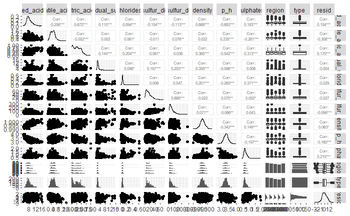

```r
red_resid %>%
  ggpairs(upper = list(continuous = wrap("cor", size = 2)))
```

Correlation to residuals indicate that volatile acids have the highest value (0.306), include this as the second predictor in the model.

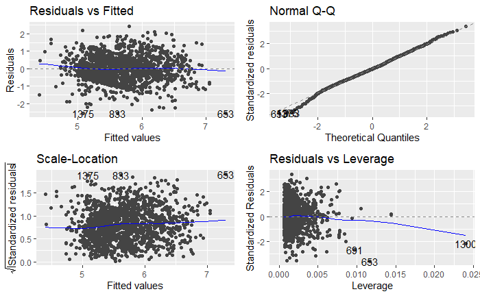

```r
mod2a_red <- lm(quality ~ alcohol + volatile_acidity, data = red_trim)

autoplot(mod2a_red)
```

```r
summary(mod2a_red)
```

```
Call:
lm(formula = quality ~ alcohol + volatile_acidity, data = red_trim)

Residuals:
     Min       1Q   Median       3Q      Max
-2.55192 -0.47030 -0.01778  0.47927  2.41435

Coefficients:
                 Estimate Std. Error t value Pr(>|t|)
(Intercept)       3.08357    0.19857   15.53   <2e-16 ***
alcohol           0.31565    0.01723   18.32   <2e-16 ***
volatile_acidity -1.34665    0.10254  -13.13   <2e-16 ***
---
Signif. codes:  0 ‘***’ 0.001 ‘**’ 0.01 ‘*’ 0.05 ‘.’ 0.1 ‘ ’ 1

Residual standard error: 0.7188 on 1596 degrees of freedom
Multiple R-squared:  0.2834,    Adjusted R-squared:  0.2825
F-statistic: 315.7 on 2 and 1596 DF,  p-value: < 2.2e-16
```

Diagnostic plots look fine, normal distribution for the residuals indicated in all plots.

R^2 = 0.2834 Statistically significant

```r
red_resid2 <- red_trim %>%
  add_residuals(model = mod2a_red) %>%
  select(-c(quality, alcohol, volatile_acidity, type))
```

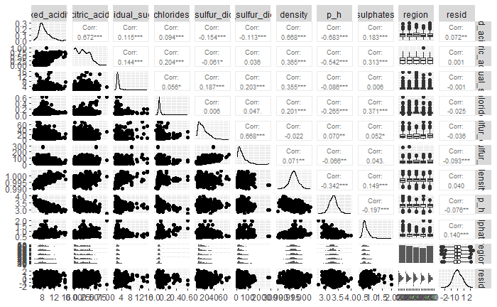

```r
red_resid2 %>%
  ggpairs(upper = list(continuous = wrap("cor", size = 2.5)))
```

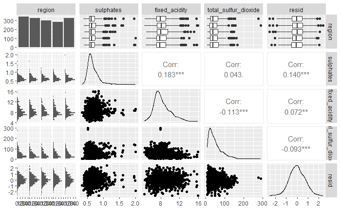

```r
red_resid2 %>%
  select(region, sulphates, fixed_acidity, total_sulfur_dioxide, resid) %>%
  ggpairs()
```

Best correlation is with sulphates, total_sulphur_dioxide and fixed_acidity. Create a model for each and compare 1. with sulphates

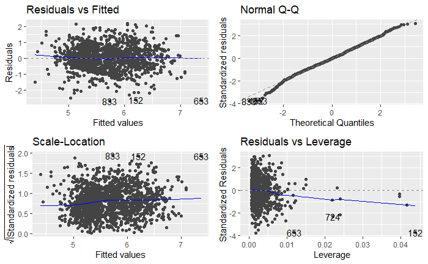

```r
autoplot(mod3a_red)
```

```r
summary(mod3a_red)
```

```
Call:
lm(formula = quality ~ alcohol + volatile_acidity + sulphates,
    data = red_trim)

Residuals:
     Min       1Q   Median       3Q      Max
-2.66345 -0.45393 -0.01326  0.48807  2.16111

Coefficients:
                 Estimate Std. Error t value Pr(>|t|)
(Intercept)       2.62881    0.21133  12.439  < 2e-16 ***
alcohol           0.31134    0.01707  18.241  < 2e-16 ***
volatile_acidity -1.19442    0.10476 -11.401  < 2e-16 ***
sulphates         0.63716    0.10886   5.853 5.84e-09 ***
---
Signif. codes:  0 ‘***’ 0.001 ‘**’ 0.01 ‘*’ 0.05 ‘.’ 0.1 ‘ ’ 1

Residual standard error: 0.7114 on 1595 degrees of freedom
Multiple R-squared:  0.2985,    Adjusted R-squared:  0.2972
F-statistic: 226.2 on 3 and 1595 DF,  p-value: < 2.2e-16
```

2. with total_sulphur dioxide

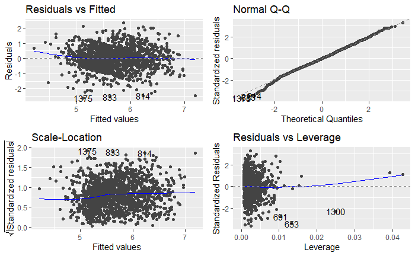

```r
mod3b_red <- lm(quality ~ alcohol + volatile_acidity + total_sulfur_dioxide, data = red_trim)

autoplot(mod3b_red)
```

```r
summary(mod3b_red)
```

```
Call:
lm(formula = quality ~ alcohol + volatile_acidity + total_sulfur_dioxide,
    data = red_trim)

Residuals:
     Min       1Q   Median       3Q      Max
-2.59857 -0.46567 -0.00493  0.47816  2.34073

Coefficients:
                       Estimate Std. Error t value Pr(>|t|)
(Intercept)           3.3098333  0.2064688  16.031  < 2e-16 ***
alcohol               0.3026720  0.0174912  17.304  < 2e-16 ***
volatile_acidity     -1.3324944  0.1021723 -13.042  < 2e-16 ***
total_sulfur_dioxide -0.0021197  0.0005566  -3.809 0.000145 ***
---
Signif. codes:  0 ‘***’ 0.001 ‘**’ 0.01 ‘*’ 0.05 ‘.’ 0.1 ‘ ’ 1

Residual standard error: 0.7157 on 1595 degrees of freedom
Multiple R-squared:  0.2899,    Adjusted R-squared:  0.2886
F-statistic: 217.1 on 3 and 1595 DF,  p-value: < 2.2e-16
```

3. with fixed_acidity

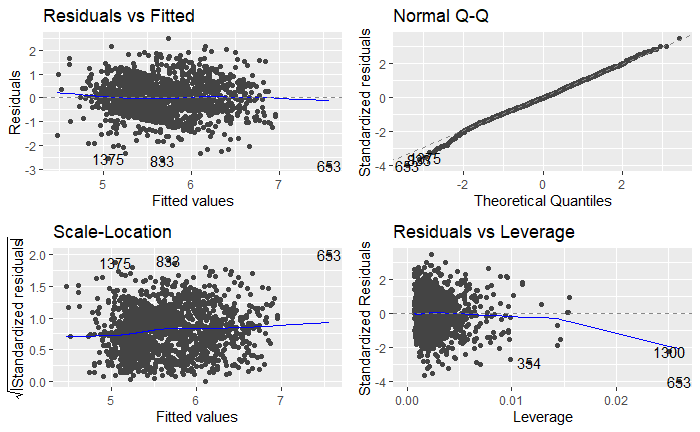

```r
mod3c_red <- lm(quality ~ alcohol + volatile_acidity + fixed_acidity, data = red_trim)

autoplot(mod3c_red)
```

```r
summary(mod3c_red)
```

```
Call:
lm(formula = quality ~ alcohol + volatile_acidity + fixed_acidity,
    data = red_trim)

Residuals:
     Min       1Q   Median       3Q      Max
-2.81122 -0.46449 -0.01739  0.48396  2.47083

Coefficients:
                 Estimate Std. Error t value Pr(>|t|)
(Intercept)       2.70148    0.23494  11.499  < 2e-16 ***
alcohol           0.32192    0.01731  18.598  < 2e-16 ***
volatile_acidity -1.25826    0.10637 -11.829  < 2e-16 ***
fixed_acidity     0.03246    0.01073   3.024  0.00254 **
---
Signif. codes:  0 ‘***’ 0.001 ‘**’ 0.01 ‘*’ 0.05 ‘.’ 0.1 ‘ ’ 1

Residual standard error: 0.7169 on 1595 degrees of freedom
Multiple R-squared:  0.2875,    Adjusted R-squared:  0.2862
F-statistic: 214.6 on 3 and 1595 DF,  p-value: < 2.2e-16
```

Comparing diagnostic plots, R2 and p_values, the best 3rd predictor (although by not much) is sulphates in mod3a_red

```r
red_resid3 <- red_trim %>%
  add_residuals(model = mod3a_red) %>%
  select(-c(quality, alcohol, volatile_acidity, type, sulphates))
```

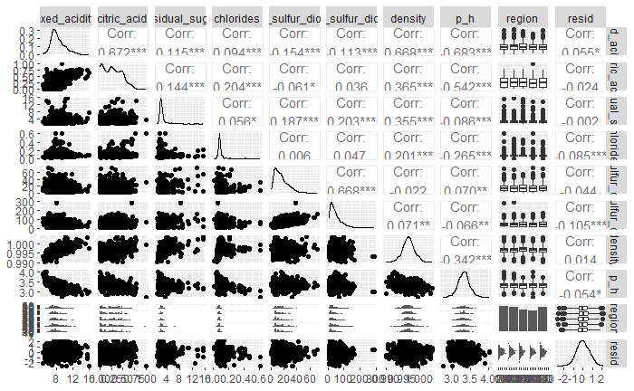

```r
red_resid3 %>%
  ggpairs()
```

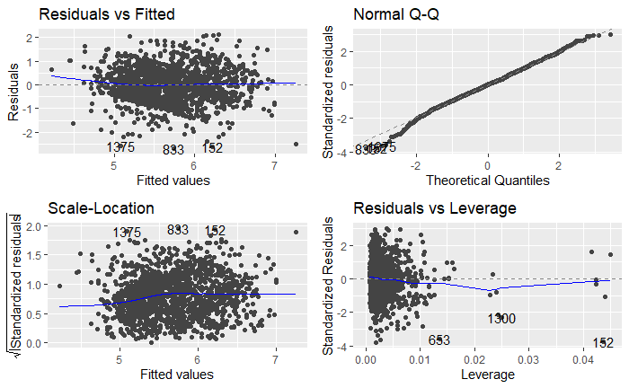

```r
autoplot(mod4_red)
```

```r
summary(mod4_red)
```

```
Call:
lm(formula = quality ~ alcohol + volatile_acidity + sulphates +
    total_sulfur_dioxide, data = red_trim)

Residuals:
     Min       1Q   Median       3Q      Max
-2.67251 -0.45155  0.00669  0.47534  2.09986

Coefficients:
                       Estimate Std. Error t value Pr(>|t|)
(Intercept)           2.8573979  0.2167746  13.181  < 2e-16 ***
alcohol               0.2965481  0.0173182  17.124  < 2e-16 ***
volatile_acidity     -1.1701363  0.1043438 -11.214  < 2e-16 ***
sulphates             0.6723700  0.1085710   6.193 7.50e-10 ***
total_sulfur_dioxide -0.0023768  0.0005517  -4.308 1.75e-05 ***
---
Signif. codes:  0 ‘***’ 0.001 ‘**’ 0.01 ‘*’ 0.05 ‘.’ 0.1 ‘ ’ 1

Residual standard error: 0.7075 on 1594 degrees of freedom
Multiple R-squared:  0.3066,    Adjusted R-squared:  0.3048
F-statistic: 176.2 on 4 and 1594 DF,  p-value: < 2.2e-16
```

Investigate the overfitting by comparing adjusted R^2, AIC and BIC for mod3a_red and mod4_red

| r.squared | adj.r.squared | AIC | BIC |
| --- | --- | --- | --- |
| 0.2985153 | 0.2971959 | 3454.748 | 3481.634 |

```r
glance(mod4_red) %>%
  select(r.squared, adj.r.squared, AIC, BIC)
```

| r.squared | adj.r.squared | AIC | BIC |
| --- | --- | --- | --- |
| 0.306589 | 0.304849 | 3438.238 | 3470.5 |

From these measurements, we can see that

R^2 is higher in the mod4_red as expected, since there is an additional element in the model compared to mod3a_red. The adjustred R^2 (which is adjusted on the number of predictors in the model) is also higher in mod4_red, suggesting that that the addition of an extra predictor in mod4_red has slightly improved the model. Furthermore, AIC and BIC are both single measurements of a good fit, are both lower in mod4_red. From this we can conclude that the model with 4 elements is better than 3.

We can interpret the 4 predictor model (from mod4_red summary) as the quality of red wine is modelled from alcohol content, volatile acidity, sulphates and total sulphur dioxide.

## White wines

```r
white_group1 <- white %>%
  select(quality, density, p_h, alcohol, region, residual_sugar)
```

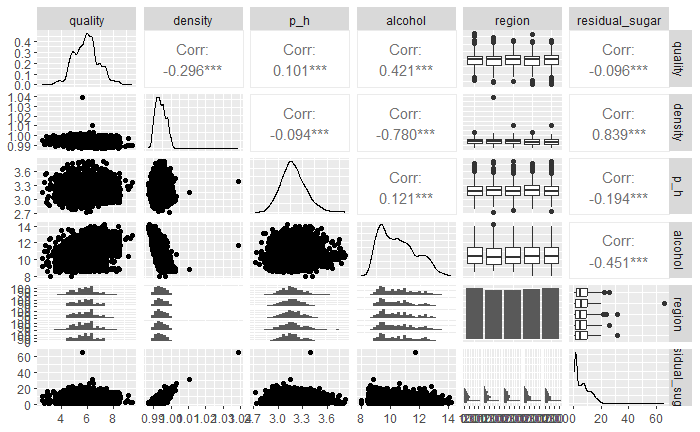

```r
white_group1 %>%
  ggpairs()
```

```r
white_group2 <- white %>%
  select(quality, fixed_acidity, volatile_acidity, citric_acid, chlorides, free_sulfur_dioxide, total_sulfur_dioxide, sulphates)
```

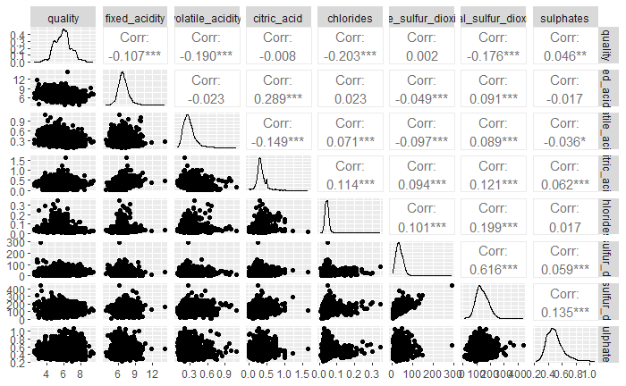

```r
white_group2 %>%
  ggpairs()
```

white wine model building

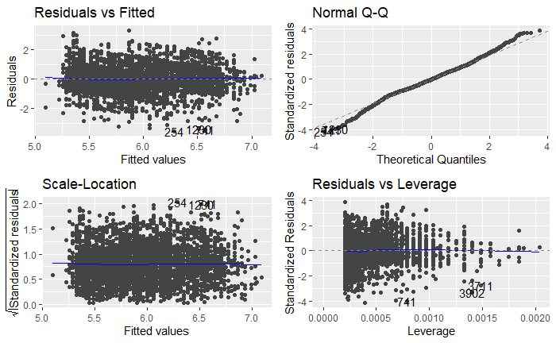

```r
white_trim <- white %>%
  select(-c(wine_id, type))

mod1_white <- lm(quality ~ alcohol, data = white_trim)

autoplot(mod1_white)
```

```r
summary(mod1_white)
```

```
Call:
lm(formula = quality ~ alcohol, data = white_trim)

Residuals:
    Min      1Q  Median      3Q     Max
-3.5247 -0.5623 -0.0207  0.5432  3.2832

Coefficients:
            Estimate Std. Error t value Pr(>|t|)
(Intercept) 2.523661   0.104913   24.05   <2e-16 ***
alcohol     0.321456   0.009911   32.44   <2e-16 ***
---
Signif. codes:  0 ‘***’ 0.001 ‘**’ 0.01 ‘*’ 0.05 ‘.’ 0.1 ‘ ’ 1

Residual standard error: 0.8535 on 4896 degrees of freedom
Multiple R-squared:  0.1769,    Adjusted R-squared:  0.1767
F-statistic:  1052 on 1 and 4896 DF,  p-value: < 2.2e-16
```

The diagnostic plots are fine, show that there is normal distribution in the residuals.

The summary shows that the R^2 is 0.1769 and the coefficient is statistically significant.

Check the residuals for the next predictor

```r
white_resid = white_trim %>%
  add_residuals(model = mod1_white) %>%
  select(-c(quality, alcohol))
```

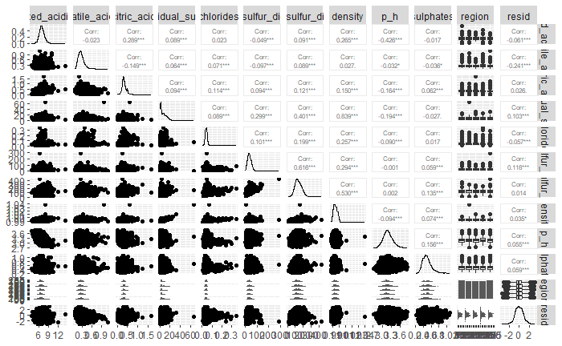

```r
white_resid %>%
  ggpairs(upper = list(continuous = wrap("cor", size = 2)))
```

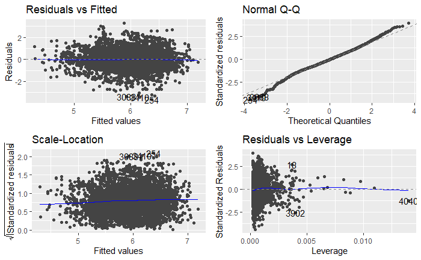

```r
mod2_white <- lm(quality ~ alcohol + volatile_acidity, data = white_trim)

autoplot(mod2_white)
```

```r
summary(mod2_white)
```

```
Call:
lm(formula = quality ~ alcohol + volatile_acidity, data = white_trim)

Residuals:
    Min      1Q  Median      3Q     Max
-3.6165 -0.5479 -0.0125  0.5235  3.2676

Coefficients:
                 Estimate Std. Error t value Pr(>|t|)
(Intercept)       2.97427    0.10506   28.31   <2e-16 ***
alcohol           0.33282    0.00964   34.52   <2e-16 ***
volatile_acidity -2.04894    0.11770  -17.41   <2e-16 ***
---
Signif. codes:  0 ‘***’ 0.001 ‘**’ 0.01 ‘*’ 0.05 ‘.’ 0.1 ‘ ’ 1

Residual standard error: 0.8283 on 4895 degrees of freedom
Multiple R-squared:  0.2249,    Adjusted R-squared:  0.2245
F-statistic:   710 on 2 and 4895 DF,  p-value: < 2.2e-16
```

```r
white_resid2 <- white_trim %>%
  add_residuals(model = mod2_white) %>%
  select(-c(quality, alcohol, volatile_acidity))
```

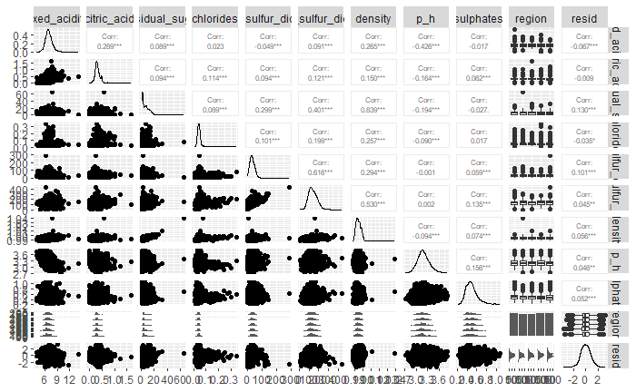

```r
white_resid2 %>%
  ggpairs(upper = list(continuous = wrap("cor", size = 2)))
```

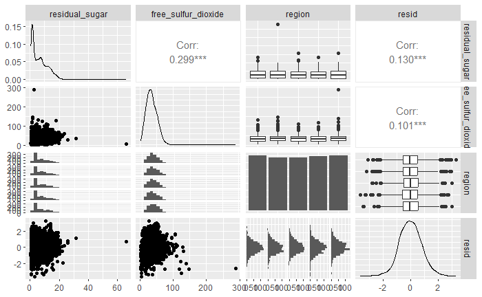

```r
white_resid2 %>%
  select(residual_sugar, free_sulfur_dioxide, region, resid) %>%
  ggpairs()
```

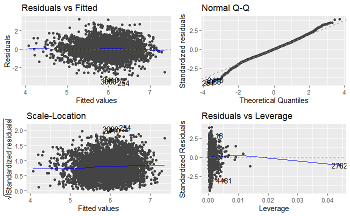

```r
mod3_white <- lm(quality ~ alcohol + volatile_acidity + residual_sugar, data = white_trim)

autoplot(mod3_white)
```

```r
summary(mod3_white)
```

```
Call:
lm(formula = quality ~ alcohol + volatile_acidity + residual_sugar,
    data = white_trim)

Residuals:
    Min      1Q  Median      3Q     Max
-3.6037 -0.5389 -0.0167  0.5150  3.1930

Coefficients:
                  Estimate Std. Error t value Pr(>|t|)
(Intercept)       2.304082   0.122414   18.82   <2e-16 ***
alcohol           0.383596   0.010722   35.77   <2e-16 ***
volatile_acidity -2.178114   0.117109  -18.60   <2e-16 ***
residual_sugar    0.026953   0.002601   10.36   <2e-16 ***
---
Signif. codes:  0 ‘***’ 0.001 ‘**’ 0.01 ‘*’ 0.05 ‘.’ 0.1 ‘ ’ 1

Residual standard error: 0.8194 on 4894 degrees of freedom
Multiple R-squared:  0.2415,    Adjusted R-squared:  0.241
F-statistic: 519.4 on 3 and 4894 DF,  p-value: < 2.2e-16
```

```r
white_resid3 <- white_trim %>%
  add_residuals(model = mod2_white) %>%
  select(-c(quality, alcohol, volatile_acidity, residual_sugar))
```

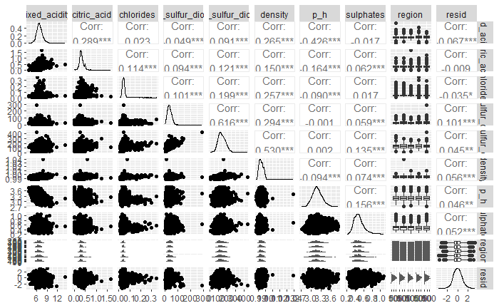

```r
white_resid3 %>%
  ggpairs()
```

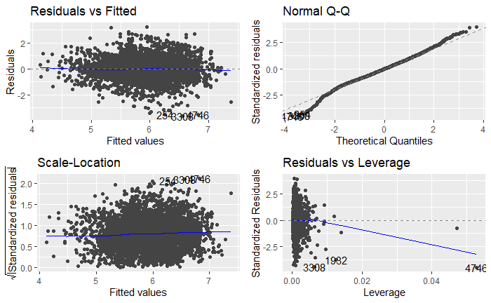

```r
autoplot(mod4_white)
```

```r
summary(mod4_white)
```

```
Call:
lm(formula = quality ~ alcohol + volatile_acidity + residual_sugar +
    free_sulfur_dioxide, data = white_trim)

Residuals:
    Min      1Q  Median      3Q     Max
-3.6025 -0.5458 -0.0151  0.5201  3.2014

Coefficients:
                      Estimate Std. Error t value Pr(>|t|)
(Intercept)          2.0977190  0.1283282  16.347  < 2e-16 ***
alcohol              0.3905591  0.0107766  36.241  < 2e-16 ***
volatile_acidity    -2.1112489  0.1174962 -17.969  < 2e-16 ***
residual_sugar       0.0238032  0.0026632   8.938  < 2e-16 ***
free_sulfur_dioxide  0.0038142  0.0007307   5.220 1.86e-07 ***
---
Signif. codes:  0 ‘***’ 0.001 ‘**’ 0.01 ‘*’ 0.05 ‘.’ 0.1 ‘ ’ 1

Residual standard error: 0.8173 on 4893 degrees of freedom
Multiple R-squared:  0.2457,    Adjusted R-squared:  0.2451
F-statistic: 398.5 on 4 and 4893 DF,  p-value: < 2.2e-16
```

The diagnostic plots looks fine, but the R^2 is 0.2457, which is lower than what we saw for 4preditor model in red wine. Let’s consider a further element.

```r
white_resid4 <- white_trim %>%
  add_residuals(model = mod4_white) %>%
  select(-c(quality, alcohol, volatile_acidity, residual_sugar, free_sulfur_dioxide))
```

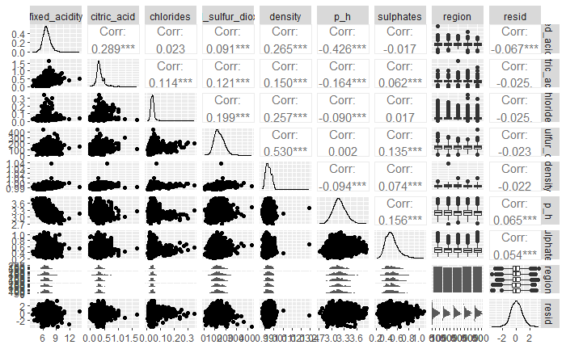

```r
white_resid4 %>%
  ggpairs()
```

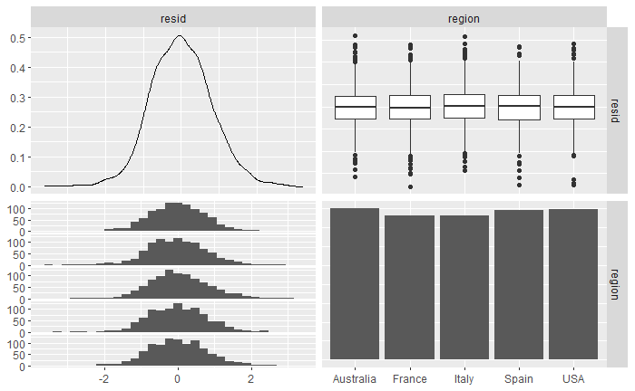

```r
white_resid4 %>%
  select(resid, region) %>%
  ggpairs()
```

Very small correlation for fixed_acidity (-0.067), will try to create model with an additional predictor but will also check for overfiting to see if it is worth it.

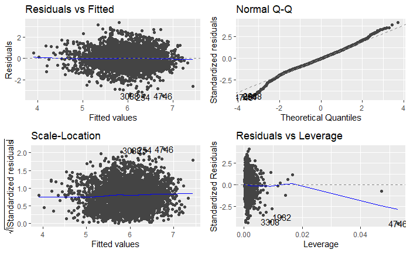

```r
autoplot(mod5_white)
```

```r
summary(mod5_white)
```

```
Call:
lm(formula = quality ~ alcohol + volatile_acidity + residual_sugar +
    free_sulfur_dioxide + fixed_acidity, data = white_trim)

Residuals:
    Min      1Q  Median      3Q     Max
-3.5753 -0.5457 -0.0217  0.5171  3.3439

Coefficients:
                      Estimate Std. Error t value Pr(>|t|)
(Intercept)          2.6174627  0.1685686  15.528  < 2e-16 ***
alcohol              0.3854448  0.0108070  35.666  < 2e-16 ***
volatile_acidity    -2.1276097  0.1172899 -18.140  < 2e-16 ***
residual_sugar       0.0245822  0.0026625   9.233  < 2e-16 ***
free_sulfur_dioxide  0.0034802  0.0007325   4.751 2.08e-06 ***
fixed_acidity       -0.0663194  0.0139891  -4.741 2.19e-06 ***
---
Signif. codes:  0 ‘***’ 0.001 ‘**’ 0.01 ‘*’ 0.05 ‘.’ 0.1 ‘ ’ 1

Residual standard error: 0.8155 on 4892 degrees of freedom
Multiple R-squared:  0.2492,    Adjusted R-squared:  0.2484
F-statistic: 324.7 on 5 and 4892 DF,  p-value: < 2.2e-16
```

```r
glance(mod5_white) %>%
  select(r.squared, adj.r.squared, AIC, BIC)
```

| r.squared | adj.r.squared | AIC | BIC |
| --- | --- | --- | --- |
| 0.2491565 | 0.2483891 | 11909.59 | 11955.06 |

```r
glance(mod4_white) %>%
  select(r.squared, adj.r.squared, AIC, BIC)
```

| r.squared | adj.r.squared | AIC | BIC |
| --- | --- | --- | --- |
| 0.245707 | 0.2450903 | 11930.04 | 11969.02 |

The R2 squared is slightly higher for mod5_white, and also the adjusted R2, which adjustes for each predictor that is added. This is also slightly higher but by quite a small amount. The AIC and BIC are both measures of “good fit” and they are both smaller for the mod5_white, but by such a small amount that I am not sure the fifth predictor is adding anything to the model, even though it is statistically significant.

I would conclude that 4 elements would be enough (the fifth is slightly better but to such a small degree) and the quality of white wines is predicted by on alcohol, volatile_acidity, residual_sugar and free_sulfur_dioxide

The equation for the white wine model is:

quality = intercept + (b1 * alcohol) + (b2 * volatile_acidity) + (b3 * residual_sugar) + (b4 * free_sulfur_dioxide) quality = 2.0977 + ( 0.391 * alcohol) + (-2.111 * volatile_acidity) + (0.0238 * residual_sugar) + (0.0038 * sulphur_dioxide)

## Automated model development.

I am curious to see how my manually developed models compare to an automated one, using the `{leaps}` package.

We just did a forward model, by adding in the predictor with the best correlation at a time, to improve the R2 of the model. In the automated model, we shall try the same approach

First, let’s compare using the best, ie takes each predictor and selects by the best R2 (essentially what we just did manually)

```r
red_regsubsets_forward <- regsubsets(quality ~ ., data = red_trim, nvmax = 15, method = "forward")

red_subsets_forward
```

[output not shown]

```r
sum_red_subsets <- summary(red_subsets_forward)

sum_red_subsets
```

[output not shown]

quality ~ alcohol + volatile_acidity + residual_sugar + density + pH + sulphates and so on.

This is interesting, as my manual model did not have density as the next most correlated predictor! The fourth predictor I tried was total_sulphur_dioxide, but very small increase was found. In the automated model, the fourth predictor is density

[figure not shown]

```r
plot(red_subsets_forward, scale = "adjr2")
```